# Assignment 7

## Question 10.1

Using the same crime data set uscrime.txt as in Questions 8.2 and 9.1, find the best model you can using (a) a regression tree model, and (b) a random forest model.  
In R, you can use the tree package or the rpart package, and the randomForest package. For each model, describe one or two qualitative takeaways you get from analyzing the results (i.e., don’t just stop when you have a good model, but interpret it too).

## Answer 10.1a

In the first part of the problem a Decision tree was used to evaluate the data. The data was not split into test and train data as the dataset is small. In the first step a decision tree was fitted to the full dataset, hereby called unpruned dataset. The R2 for this model is 72% similar to what we got with linear regression in the previous exercise. A cross validation was run on the unpruned dataset to spot overfitting. The cross validating process revels overfitting which can be expected with this small dataset. Further prunning is done and the same process is followed. Again the R2 does get lower with lowering the size of the tree and overfitting was prominent.

```r
library(ggplot2)
library(randomForest)
library(tree)

#Getting the training and test data
crime_data<-read.table('uscrime.txt', sep = "", header = TRUE)
test<-read.table('test.txt', sep="", header = TRUE)

#Now fitting an unpruned regression tree to the training data
lmr<-tree(Crime~., data=crime_data)
summary(lmr)
```

```
##
## Regression tree:
## tree(formula = Crime ~ ., data = crime_data)
## Variables actually used in tree construction:
## [1] "Po1" "Pop" "LF"  "NW"
## Number of terminal nodes:  7
## Residual mean deviance:  47390 = 1896000 / 40
## Distribution of residuals:
##     Min.  1st Qu.   Median     Mean  3rd Qu.     Max.
## -573.900  -98.300   -1.545    0.000  110.600  490.100
```

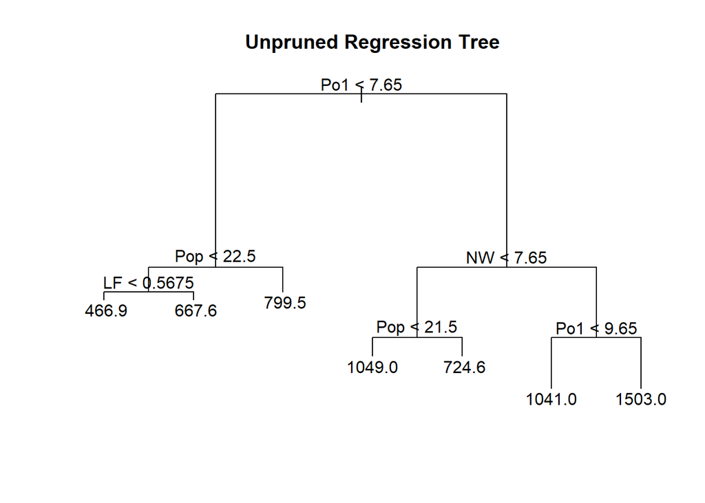

```r
#Visualization
plot(lmr)
text(lmr, pretty = 0)
title(main = "Unpruned Regression Tree")
```

```r
#predicting using the unpruned model
pred_un<-predict(lmr, crime_data[,1:15])

#Calculating R2 for the unpruned model
SSE<-sum((pred_un-crime_data[16])^2)
SST<-sum((crime_data$Crime-mean(crime_data$Crime))^2)
R2<-1-SSE/SST

#As with classification trees, we can use cross-validation to select a good
#pruning of the tree.
set.seed(18)
lmr_cv = cv.tree(lmr)
summary(lmr_cv)
```

```
##        Length Class  Mode
## size   7      -none- numeric
## dev    7      -none- numeric
## k      7      -none- numeric
## method 1      -none- character
```

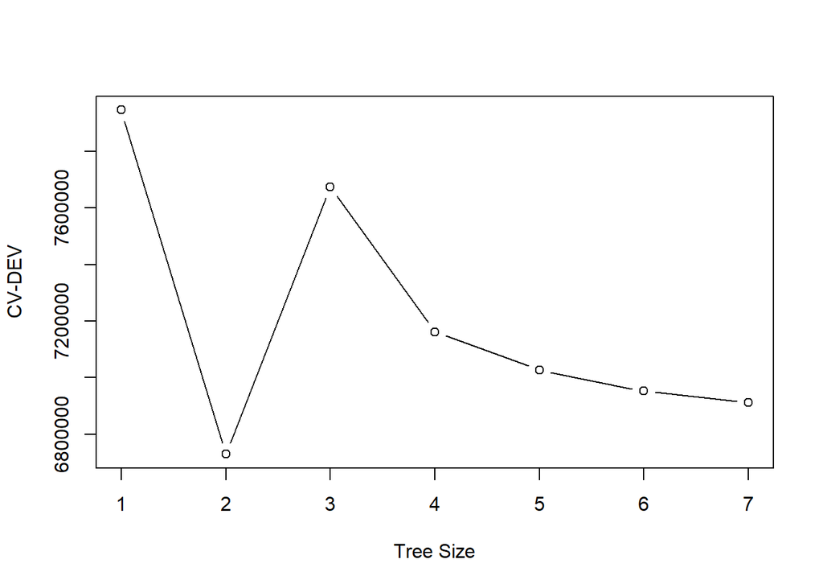

```r
plot(lmr_cv$size,lmr_cv$dev, type = "b",
     xlab = "Tree Size", ylab = "CV-DEV")
```